# t-Test and Anova, refresh

F.A. Barrios Instituto de Neurobiología UNAM

2025-10-16

# Examples for t-test and ANOVA

Examples of problems taken from chapter 3 (Vittinghoff’s book http://www.biostat.ucsf.edu/vgsm) using data from the heart and estrogen/progestin study (HERS), a clinical trial of hormone therapy (HT) for prevention of recurrent heart attacks and death among 2,763 post-menopausal women with existing coronary heart disease (CHD). Also we will present some exercises from Daniel’s book too, and this will cover a refresher for t-test and ANOVA (assuming parametric distributions).

## Introduction.

To execute two sample comparisons the simplest is the best, as always we must apply Occam’s razor. So the classical tests to estimate comparisons between two samples are some of the most frequently-used kinds of analysis and we have the R functions:

- Comparing two variables Fisher’s F test (`var.test`)
- Comparing two sample means with normal errors Student’s t test (`t.test`)
- Comparing two sample means with non-normal errors Wilcoxon’s test (`wilcoxon.test`)
- Comparing two proportions the binomial test (`prop.test`)
- Correlating two variables, Pearson’s or Spearman’s rank correlation (`cor.test`)
- testing for independence in contingency tables chi-squared (`chisq.test`)
- testing small samples for correlation Fisher’s exact test (`fisher.test`)

We will cover some basic tools for assessing the statistical significance of differences between the average values of a continuous outcome across two or more samples following parametric statistics are the t-Test and ANOVA.  
The example presented in (chapter 3 Table 3) of the t-Test of differences in glucose average combined with exercise for the women that are not diabetic in the HERS data set. These examples are to revisit some t-test R estimations and t-test function in R. And to remember that a **boxplot** gives a good amount of information about a numerical variable:

- **Centering** described by the median.
- **Dispersion**, measured by the high of the box (*interquartil* distance).
- **Observation range** The presence of extreme values (*outliers*).

And some information of the distribution “linked to skewness”.  
If the median (the bold line) is located toward the bottom of the box, then the data are *right-skewed* toward larger values. That is, the distance between the median and the 75th percentile is greater than that between the median and the 25th percentile. Likewise, right-skewness will be indicated if the upper whisker is longer than the lower whisker or if there are more outliers in the upper range.

```r
# To load the CRAN libraries used
library(multcomp)
library(tidyverse)
library(car)
library(emmeans)
```

```r
HERS <- read_csv("https://raw.githubusercontent.com/fabarrios/Regression/master/DataRegressBook/Chap3/hersdata.csv", show_col_types = FALSE)
# Loading the HERS database in HERS variable
names(HERS)
```

```
 [1] "HT"       "age"      "raceth"   "nonwhite" "smoking"  "drinkany"
 [7] "exercise" "physact"  "globrat"  "poorfair" "medcond"  "htnmeds"
[13] "statins"  "diabetes" "dmpills"  "insulin"  "weight"   "BMI"
[19] "waist"    "WHR"      "glucose"  "weight1"  "BMI1"     "waist1"
[25] "WHR1"     "glucose1" "tchol"    "LDL"      "HDL"      "TG"
[31] "tchol1"   "LDL1"     "HDL1"     "TG1"      "SBP"      "DBP"
[37] "age10"
```

```r
summary(HERS)
```

```
      HT                 age           raceth            nonwhite
 Length:2763        Min.   :44.00   Length:2763        Length:2763
 Class :character   1st Qu.:62.00   Class :character   Class :character
   smoking            drinkany           exercise           physact
 Length:2763        Length:2763        Length:2763        Length:2763
 Class :character   Class :character   Class :character   Class :character
   globrat            poorfair            medcond         htnmeds
 Length:2763        Length:2763        Min.   :0.0000   Length:2763
 Class :character   Class :character   1st Qu.:0.0000   Class :character
   statins            diabetes           dmpills            insulin
 Length:2763        Length:2763        Length:2763        Length:2763
 Class :character   Class :character   Class :character   Class :character
     weight            BMI            waist             WHR
 Min.   : 37.50   Min.   :15.21   Min.   : 56.90   Min.   :0.624
 1st Qu.: 62.20   1st Qu.:24.64   1st Qu.: 82.00   1st Qu.:0.811
    glucose         weight1            BMI1           waist1
 Min.   : 29.0   Min.   : 37.70   Min.   :14.73   Min.   : 59.00
 1st Qu.: 91.0   1st Qu.: 61.20   1st Qu.:24.34   1st Qu.: 81.30
      WHR1           glucose1         tchol            LDL
 Min.   :0.6060   Min.   : 42.0   Min.   :110.0   Min.   : 36.8
 1st Qu.:0.8100   1st Qu.: 91.0   1st Qu.:201.0   1st Qu.:119.6
      HDL               TG            tchol1           LDL1
 Min.   : 14.00   Min.   : 31.0   Min.   : 92.0   Min.   :-20.0
 1st Qu.: 41.00   1st Qu.:116.0   1st Qu.:193.0   1st Qu.:106.6
      HDL1             TG1              SBP             DBP
 Min.   : 14.00   Min.   :  31.0   Min.   : 83.0   Min.   : 45.00
 1st Qu.: 42.00   1st Qu.: 119.0   1st Qu.:122.0   1st Qu.: 67.00
     age10
 Min.   :4.400
 1st Qu.:6.200
 [ reached 'max' / getOption("max.print") -- omitted 5 rows ]
```

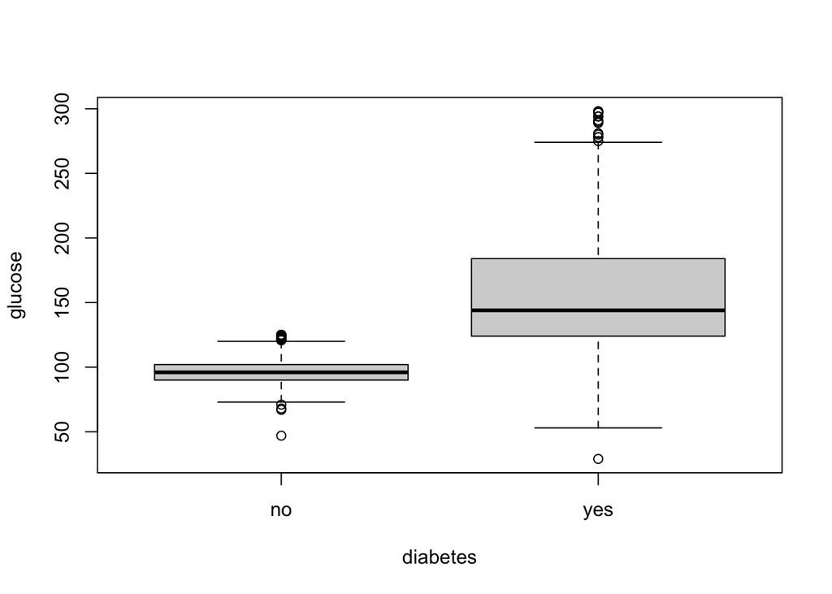

```r
boxplot(glucose ~ diabetes, data=HERS)
```

Before we can compare two sample means we need to test whether the sample variances are significantly different. The test statistic to compare two variances, is the Fisher’s test, where you divide the larger variance by the smaller variance, if the variances are similar the ratio will be close to 1. How do we know if the test statistic value is low or large? We look for the critical value of the Fisher’s *F*. In R there is an build in `var.test` with null hypothesis assuming the variances are the same, a large value of *p*. for Significantly different variances you can discard the null hypothesis (*p* smaller than $\alpha$)

```r
var.test(glucose[HERS$diabetes == "no"] ~ exercise[HERS$diabetes == "no"],
       data=HERS,
       alternative="two.sided")
```

```
    F test to compare two variances

data:  glucose[HERS$diabetes == "no"] by exercise[HERS$diabetes == "no"]
F = 1.0971, num df = 1190, denom df = 840, p-value = 0.1483
alternative hypothesis: true ratio of variances is not equal to 1
95 percent confidence interval:
 0.9675117 1.2422701
sample estimates:
ratio of variances
          1.097065
```

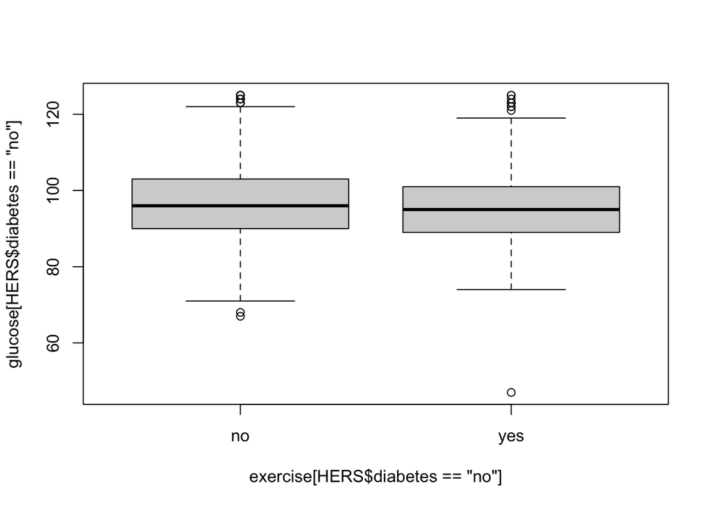

```r
# Some graphical description of the glucose state
boxplot(glucose[HERS$diabetes == "no"] ~ exercise[HERS$diabetes == "no"], data=HERS)
```

```r
t.test(glucose[HERS$diabetes == "no"] ~ exercise[HERS$diabetes == "no"], data=HERS, alternative="two.sided", mu=0, var.equal=TRUE)
```

```
    Two Sample t-test

data:  glucose[HERS$diabetes == "no"] by exercise[HERS$diabetes == "no"]
t = 3.8685, df = 2030, p-value = 0.000113
alternative hypothesis: true difference in means between group no and group yes is not equal to 0
95 percent confidence interval:
 0.8346242 2.5509539
sample estimates:
 mean in group no mean in group yes
         97.36104          95.66825
```

We reject the null hypothesis the glucose measurement is higher for the subjects that do not exercise, note that the confidence interval on the difference does not include zero.

## *t*-test examles

Examples of *t*-test from the exercises of the Daniel’s book, Chap 7, section 3 number 3. Data can be downloaded from the WEB page of the Daniel’s book. Hoekema et al. studied the craniofacial morphology of 26 male patients with obstructive sleep apnea syndrome (OSAS) and 37 healthy male subjects (non-OSAS). One of the variables of interest was the length from the most superoanterior point of the body of the hyoid bone to the Frankfort horizontal (measured in millimeters).

```r
# Daniel's chap 7 t-test examples
# EXR_C07_S03_03

Ex733 = read_csv(file="https://raw.githubusercontent.com/fabarrios/Regression/master/DataSets/ch07_all/EXR_C07_S03_03.csv", show_col_types = FALSE)
names(Ex733)
```

```
[1] "Length" "Group"
```

```r
summary(Ex733)
```

```
     Length           Group
 Min.   : 88.25   Min.   :1.000
 1st Qu.: 94.55   1st Qu.:1.000
 Median :101.00   Median :1.000
 Mean   :102.13   Mean   :1.413
 3rd Qu.:109.47   3rd Qu.:2.000
 Max.   :128.95   Max.   :2.000
```

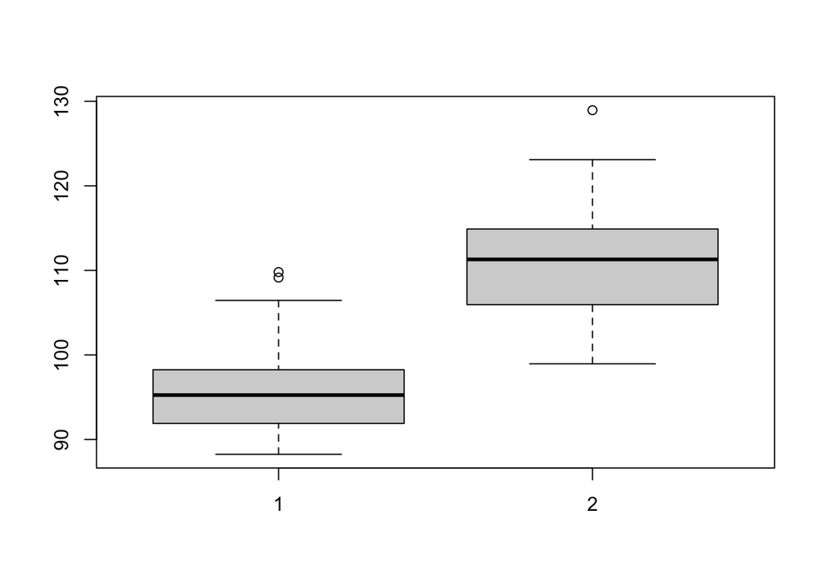

```r
# In parts
NoOSAS = Ex733$Length[Ex733$Group == 1]
OSAS = Ex733$Length[Ex733$Group == 2]
#
boxplot(NoOSAS, OSAS)
```

```r
var.test(OSAS, NoOSAS)
```

```
    F test to compare two variances

data:  OSAS and NoOSAS
F = 1.5494, num df = 25, denom df = 36, p-value = 0.2253
alternative hypothesis: true ratio of variances is not equal to 1
95 percent confidence interval:
 0.7606111 3.3152356
sample estimates:
ratio of variances
          1.549382
```

```r
t.test(NoOSAS, OSAS, alternative="less", conf.level = 0.99)
```

```
    Welch Two Sample t-test

data:  NoOSAS and OSAS
t = -9.2441, df = 46.217, p-value = 2.229e-12
alternative hypothesis: true difference in means is less than 0
99 percent confidence interval:
      -Inf -11.24172
sample estimates:
mean of x mean of y
 95.85405 111.05962
```

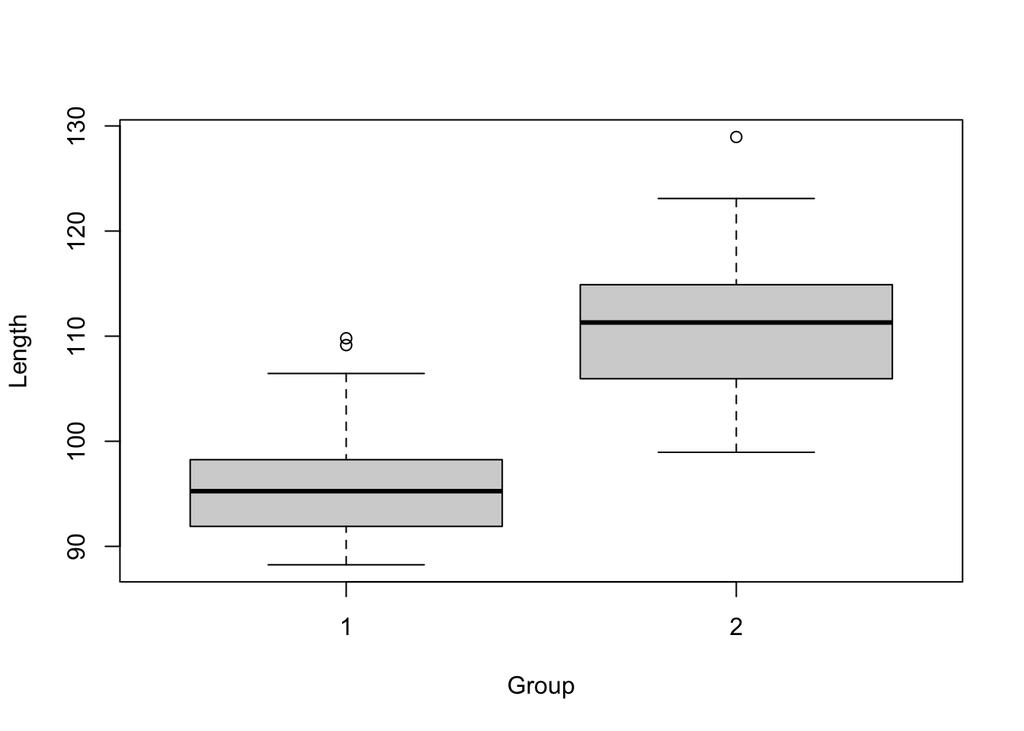

```r
#
# Shorter and direct
boxplot(Length ~ Group, data = Ex733)
```

```r
t.test(Length ~ Group, data = Ex733, alternative = "less", conf.level = 0.99)
```

```
    Welch Two Sample t-test

data:  Length by Group
t = -9.2441, df = 46.217, p-value = 2.229e-12
alternative hypothesis: true difference in means between group 1 and group 2 is less than 0
99 percent confidence interval:
      -Inf -11.24172
sample estimates:
mean in group 1 mean in group 2
       95.85405       111.05962
```

How it looks for several variables an ANOVA example using the HERS data referring to the diabetic participants.

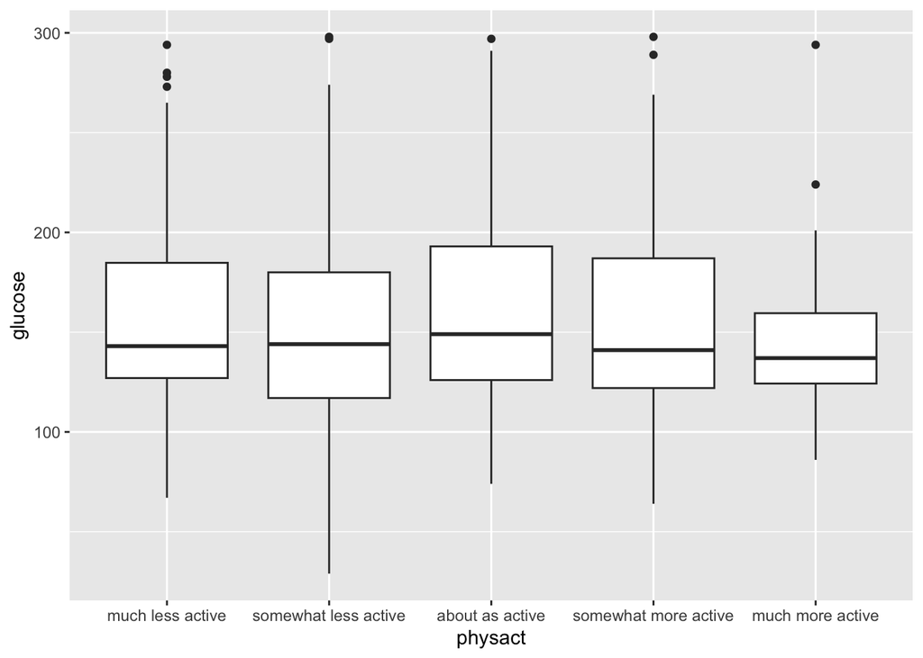

```r
# Example of the HERS data for diabetic participants
# hers_yesdi <- filter(HERS, diabetes == "yes")
hers_yesdi <- HERS %>%
  filter(diabetes == "yes") %>%
  mutate(physact = factor(physact, levels=c("much less active","somewhat less active","about as active","somewhat more active","much more active")))

#  Example of ANOVA with HERS data for diabetic participants
#
ggplot(data = hers_yesdi, mapping = aes(x = physact, y = glucose)) +
  geom_boxplot(na.rm = TRUE)
```

```r
glucose_yesdi_activ <- aov(glucose ~ physact, data = hers_yesdi)
glucose_yesdi_activ
```

```
Call:
   aov(formula = glucose ~ physact, data = hers_yesdi)

Terms:
                  physact Residuals
Sum of Squares    17991.6 1696313.1
Deg. of Freedom         4       726

Residual standard error: 48.33756
Estimated effects may be unbalanced
```

```r
# Or print the anova table using the car package function
Anova(glucose_yesdi_activ, type="II")
```

```
Anova Table (Type II tests)

Response: glucose
           Sum Sq  Df F value Pr(>F)
physact     17992   4   1.925 0.1044
Residuals 1696313 726
```

```r
#
S(glucose_yesdi_activ)
```

```
Call: aov(formula = glucose ~ physact, data = hers_yesdi)

Coefficients:
                            Estimate Std. Error t value Pr(>|t|)
(Intercept)                  155.789      5.095  30.575   <2e-16 ***
physactsomewhat less active   -4.590      6.235  -0.736    0.462
physactabout as active         5.191      5.958   0.871    0.384
physactsomewhat more active   -1.398      6.362  -0.220    0.826
physactmuch more active      -11.789      8.320  -1.417    0.157
---
Signif. codes:  0 '***' 0.001 '**' 0.01 '*' 0.05 '.' 0.1 ' ' 1

Residual standard deviation: 48.34 on 726 degrees of freedom
Multiple R-squared: 0.0105
F-statistic: 1.925 on 4 and 726 DF,  p-value: 0.1044
    AIC     BIC
7751.41 7778.98
```

```r
glucose_emmeans <- emmeans(glucose_yesdi_activ, "physact")
contrast(glucose_emmeans, adjust="sidak")
```

```
 contrast                    estimate   SE  df t.ratio p.value
 much less active effect         2.52 4.45 726   0.565  0.9856
 somewhat less active effect    -2.07 3.46 726  -0.599  0.9815
 about as active effect          7.71 3.16 726   2.441  0.0722
 somewhat more active effect     1.12 3.60 726   0.311  0.9991
 much more active effect        -9.27 5.50 726  -1.687  0.3830

P value adjustment: sidak method for 5 tests
```

# Example from R-bloggers

Plotting data distributions of random data to do an example of ggplot color filling. First we build four random variables with two different distributions. And then followed of a ggplot command using the color to distinguish the variables.

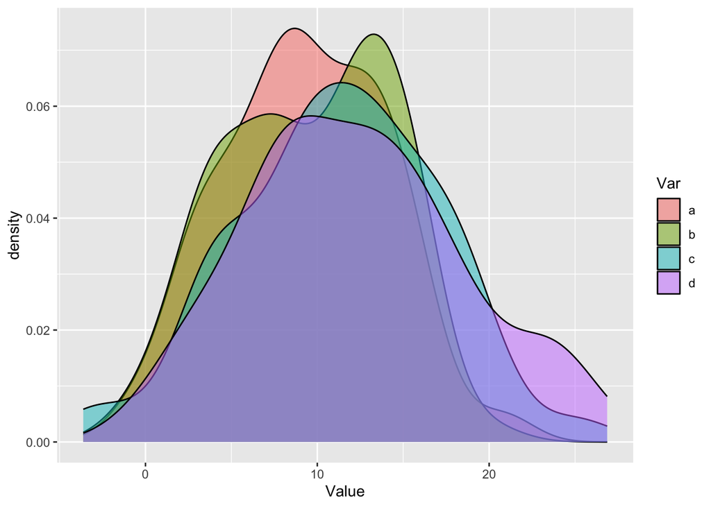

```r
# Create the four groups
set.seed(10)
df1 <- data.frame(Var="a", Value=rnorm(100,10,5))
df2 <- data.frame(Var="b", Value=rnorm(100,10,5))
df3 <- data.frame(Var="c", Value=rnorm(100,11,6))
df4 <- data.frame(Var="d", Value=rnorm(100,11,6))

# merge them in one data frame
df<-rbind(df1,df2,df3,df4)

# convert Var to a factor
df$Var <- as.factor(df$Var)
df %>% ggplot(aes(x=Value, fill=Var)) + geom_density(alpha=0.5)
```

## The ANOVA (taken from R-bloggers)

ANOVA (ANalysis Of VAriance) is a statistical test used to compare two or more groups to see if they are significantly different. The ANOVA model and some examples. The null hypothesis in ANOVA is that there is no difference between means and the alternative is that the means are not all equal. This means that when we are dealing with many groups, we cannot compare them pairwise. We can simply answer if the means between groups can be considered as equal or not.

```r
# ANOVA
model1 <- aov(Value ~ Var, data=df)
anova(model1)
```

```
Analysis of Variance Table

Response: Value
           Df  Sum Sq Mean Sq F value    Pr(>F)
Var         3   565.7 188.565   6.351 0.0003257 ***
Residuals 396 11757.5  29.691
---
Signif. codes:  0 '***' 0.001 '**' 0.01 '*' 0.05 '.' 0.1 ' ' 1
```

## Tukey multiple comparisons

What about if we want to compare all the groups pairwise? In this case, we can apply the Tukey’s HSD which is a single-step multiple comparison procedure and statistical test, Tukey’s Honest Significant Difference (Tukey’s HSD). It can be used to find means that are significantly different from each other.

```r
summary(glht(model1, mcp(Var="Tukey")))
```

```
     Simultaneous Tests for General Linear Hypotheses

Multiple Comparisons of Means: Tukey Contrasts


Fit: aov(formula = Value ~ Var, data = df)

Linear Hypotheses:
           Estimate Std. Error t value Pr(>|t|)
b - a == 0   0.2079     0.7706   0.270  0.99312
c - a == 0   1.8553     0.7706   2.408  0.07727 .
d - a == 0   2.8758     0.7706   3.732  0.00129 **
c - b == 0   1.6473     0.7706   2.138  0.14298
d - b == 0   2.6678     0.7706   3.462  0.00329 **
d - c == 0   1.0205     0.7706   1.324  0.54795
---
Signif. codes:  0 '***' 0.001 '**' 0.01 '*' 0.05 '.' 0.1 ' ' 1
(Adjusted p values reported -- single-step method)
```